# Revenue Forecast(Time Series Research)

PLZ

April 26, 2016

### >**Introduction**

**This research project is to carry out some simple analysis on time series data extracted from Insight(Cases from 2011 to 2015) and forecast revenue of the next 10 month from now on.**

#### 1. Read data from Insigtht and Pre-processing

```r
# Read data from Insigtht, the first part of data includes the cases(2012-2013), the second part of data includes the cases(2014-2015)
data1 <- read.csv("C:/Users/pzhou/Data/PartsExtract 07.01.2012 - 07.26.2013.csv")
data2 <- read.csv("C:/Users/pzhou/Data/2014-2015 020516.csv")
#str(data1)
#str(data2)
```

```r
#Change variable type from factor to numeric, date respectively
data11<-transform(data1,Rev=as.numeric(Rev),sched_surgery=as.character(sched_surgery))
data11$sched_surgery= as.Date(data11$sched_surgery,format='%m/%d/%Y')
data2.new<-transform(data2,rev=as.numeric(rev),DOS_Month=as.numeric(DOS_Month))
data2.new$billmonth<-as.Date(data2.new$billmonth,format='%m/%d/%Y')
```

```r
# Use lubridate to get the year and month value from date
library(lubridate)
data11$Year= year(data11$sched_surgery)
data11$Month= month(data11$sched_surgery)
data11$YearAndMonth= format(data11$sched_surgery,"%m/%Y")
data2.new$Year= year(data2.new$billmonth)
data2.new$Month= month(data2.new$billmonth)
data2.new$YearAndMonth=format(data2.new$billmonth,"%m/%Y")
data2.new$Rev=data2.new$rev
```

```r
#get some variables(time related) and y(rev)
data11.sub1<-subset(data11,subset= Year== 2012|2013,select=c(Year,Month,YearAndMonth,Rev))
data2.new.sub<-subset(data2.new,select=c(Year,Month,YearAndMonth,Rev))
```

```r
# sort the data order by time(YearAndMonth)
attach(data11.sub1)
newdata1 <- data11.sub1[order(Year,Month),]
detach(data11.sub1)
attach(data2.new.sub)
Part2data <- data2.new.sub[order(Year,Month),]
detach(data2.new.sub)
```

**Some missing value occured in revenue variable on some time point, so we need to deal with missing value in case influncing the sum operation of revenue each month later.**

```r
# Exclude the missing value of revenue
newdata1.el<-na.exclude(newdata1) # after exclude, the obs number will decrease
Part2data.el<-na.exclude(Part2data)
```

```r
# Merge the two dataset
alldata<-rbind(newdata1.el,Part2data.el)
```

```r
# Calculate the total revenue for each month
library(data.table)
alldata.ready<-data.table(alldata)[, list(sumofRev=sum(Rev)), by=YearAndMonth]
head(alldata.ready)
```

```
##    YearAndMonth sumofRev
## 1:      12/2011  3279.04
## 2:      01/2012  7316.10
## 3:      02/2012  1658.04
## 4:      03/2012 30129.00
## 5:      04/2012 17323.92
## 6:      05/2012 60989.60
```

#### 2. Make it as time series data

```r
revtimeseries <- ts(alldata.ready$sumofRev, frequency=12, start=c(2011,12))
```

#### 3. Plot Time Series

**Revenue Plot for each month(2012-2015)**

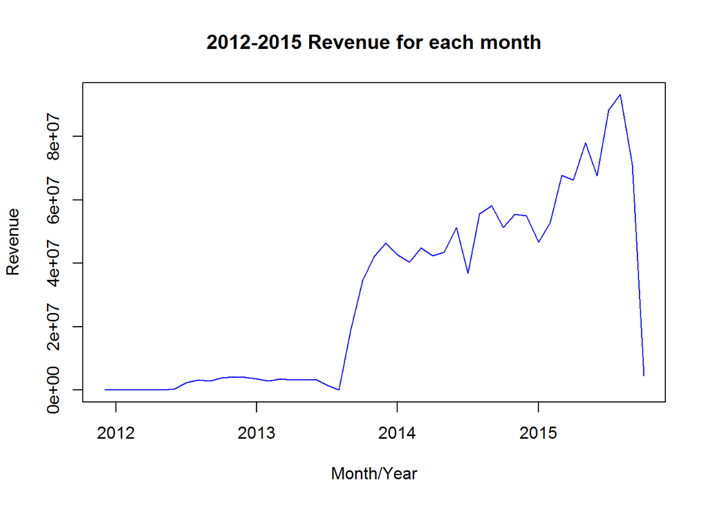

**This plot shows that it appears an additive mode is not appropriate for describing this time series, since the size of the seasonal fluctuations and random fluctuations seem to increase with the level of the time series. Thus, we may need to transform the time series by calculating the natural log of the original data in order to get a transformed time series that can be described using an additive model.**

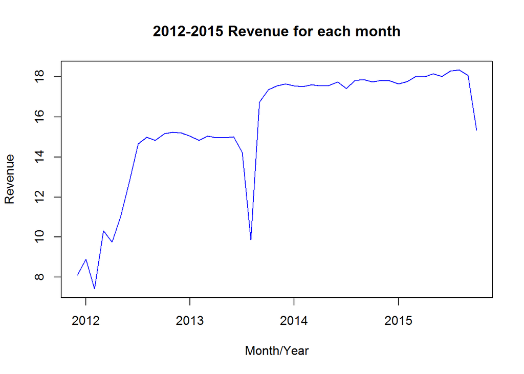

**It appears that the size of the seasonal fluctuations and random fluctuations in the log-transformed time series seem to be roughly constant over time, and do not depend on the level of the time series. Thus, this log-transformed time series can probably be described using an additive model.**

**Here we would estimate the trend through smoothing time series data to help look at the trend of data. Thus, we use a simple moving average(SMA) method to smooth time series data with order=9.**

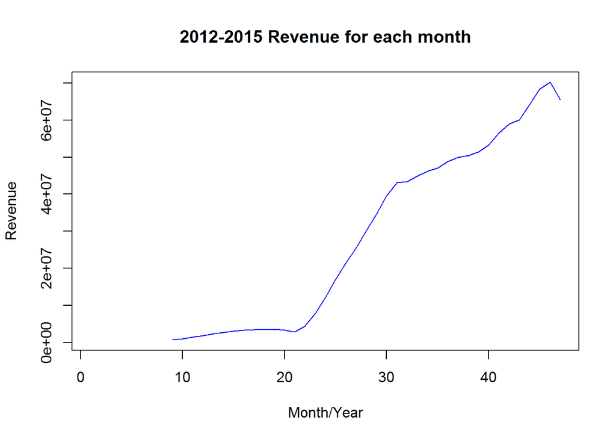

**The data smoothed with a simple moving average of order 9 gives a clearer picture of the trend component, and we can see that the revenue seems to have continuously increase from 2012 to 2015, and specially fast increase from 2013 to 2014.**

**Next we will estimate the seasonal component, trend component and random component through decomposing time series data to have a look at the seasonal, trend and random object respectively.**

```r
#Use decompose() to get the estimated values of 3 components: seasonal, trend, random components
revtimeseriescomponents <- decompose(revtimeseries)
revtimeseriescomponents$seasonal
```

```
##             Jan        Feb        Mar        Apr        May        Jun
## 2011
## 2012 -1180249.8 -2575275.5  1900773.3  -432190.7 -3559438.6 -1321753.9
## 2013 -1180249.8 -2575275.5  1900773.3  -432190.7 -3559438.6 -1321753.9
## 2014 -1180249.8 -2575275.5  1900773.3  -432190.7 -3559438.6 -1321753.9
## 2015 -1180249.8 -2575275.5  1900773.3  -432190.7 -3559438.6 -1321753.9
##             Jul        Aug        Sep        Oct        Nov        Dec
## 2011                                                         5109826.6
## 2012 -7472642.7 -2785981.2  2385841.8  3959620.3  5971470.6  5109826.6
## 2013 -7472642.7 -2785981.2  2385841.8  3959620.3  5971470.6  5109826.6
## 2014 -7472642.7 -2785981.2  2385841.8  3959620.3  5971470.6  5109826.6
## 2015 -7472642.7 -2785981.2  2385841.8  3959620.3
```

```r
revtimeseriescomponents$trend
```

```
##           Jan      Feb      Mar      Apr      May      Jun      Jul
## 2011
## 2012       NA       NA       NA       NA       NA  1568040  1878845
## 2013  3278015  3110432  3637397  5579155  8445817 11793627 15191483
## 2014 35512384 39308782 43272626 45614094 46863119 47776736 48304109
## 2015 59794883 63502493 65607940 64199324       NA       NA       NA
##           Aug      Sep      Oct      Nov      Dec
## 2011                                           NA
## 2012  2138484  2397773  2672445  2933882  3187659
## 2013 18391750 21680423 25038382 28353726 32035858
## 2014 48991678 50466286 52416722 54852698 56971338
## 2015       NA       NA       NA
```

```r
revtimeseriescomponents$random
```

```
##               Jan          Feb          Mar          Apr          May
## 2011
## 2012           NA           NA           NA           NA           NA
## 2013   1353859.41   2253518.16  -2072111.83  -1973447.02  -1707099.66
## 2014   8383636.70   3597420.88   -321437.88  -2803279.06    238742.60
## 2015 -11940031.70  -8053474.62    191014.12   2574190.49           NA
##               Jun          Jul          Aug          Sep          Oct
## 2011
## 2012     93003.12   7904796.50   3885114.04  -2009793.19  -2771304.35
## 2013  -7160230.73  -6211648.38 -15586336.87  -5427091.03   5599586.72
## 2014   4864692.03  -3895683.70   9498687.25   5234348.64  -5030817.95
## 2015           NA           NA           NA           NA           NA
##               Nov          Dec
## 2011                        NA
## 2012  -4739557.09  -4279194.87
## 2013   7903661.59   9157003.27
## 2014  -5366640.08  -7080343.99
## 2015
```

**For seasonality of this time series data, it is indicating that revenue is seasonal with a peak every November and a trough every July, and a small peak occured on every March. Below plot the trend, seasonal and random component of the revenue data.**

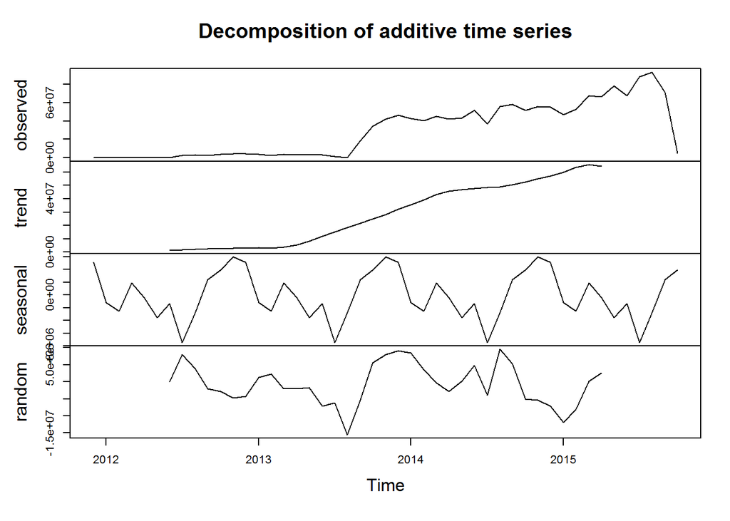

**Below plot the seasonally adjusted time seires through removing the seasonal component. This plot just contains the trend and random component.**

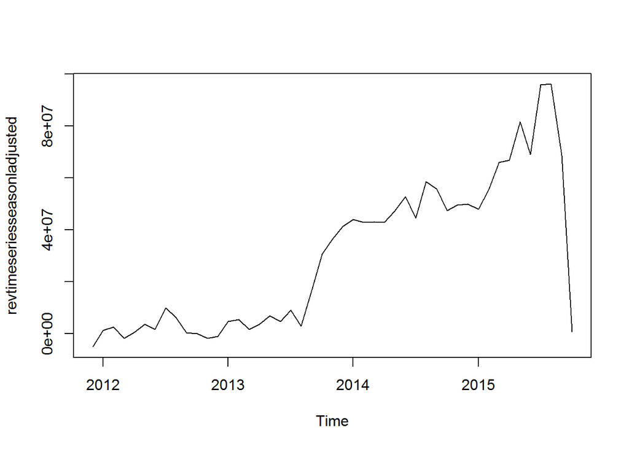

#### 4. Revenue Forecast Using Holt-Winters Exponential Smoothing

**Considering this time seires using additive model with increasing trend and seasonality, we use the Holt-Winters exponetial smoothing to make forcast.** **Typically,** **1.simple exponential smoothing is using for an additive model with constant level and no seasonality;** **2.Holt’s Exponential smoothing is using for an additive model with increasing or decreasing trend and no seasonality;** **3.Holt-Winters Exponetial smoothing is using for an additive model with increasing or decreasing trend and seasonality.**

##### **4.1 Fit the model**

```
## Holt-Winters exponential smoothing with trend and additive seasonal component.
##
## Call:
## HoltWinters(x = logrevtimeseries)
##
## Smoothing parameters:
##  alpha: 0.7714782
##  beta : 0
##  gamma: 0.3593684
##
## Coefficients:
##           [,1]
## a   15.5364480
## b    0.2246882
## s1   0.0424243
## s2  -0.1136346
## s3  -0.5143220
## s4  -0.5919651
## s5  -0.2956407
## s6  -0.4866282
## s7  -0.6414855
## s8  -0.2882814
## s9   0.7778771
## s10  0.6084971
## s11  0.7668806
## s12  0.1993514
```

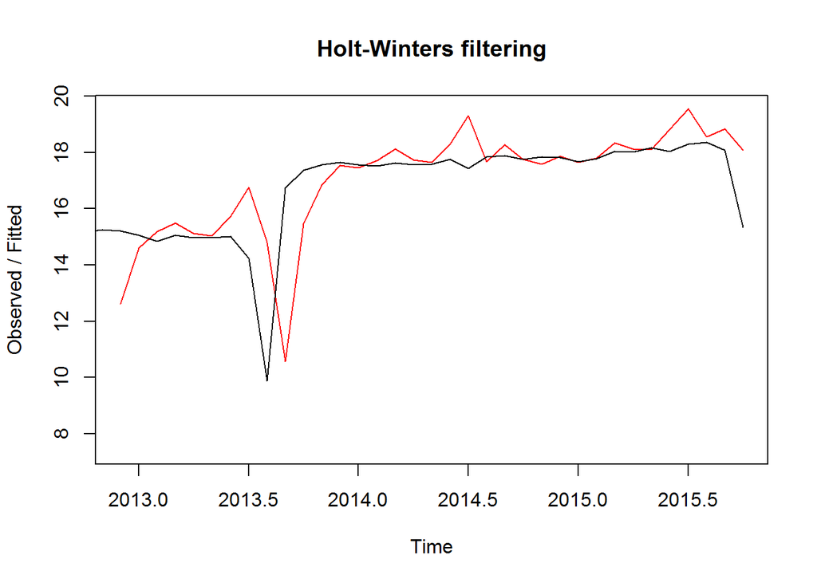

```
## [1] 95.57493
```

##### **4.2 Forecast**

**To make forecast for the future 10 months using the forecast.HoltWinters() function to provide a 80% prediction interval for the forecast, and a 95% prediction interval for the forecast.**

```
##          Point Forecast    Lo 80    Hi 80     Lo 95    Hi 95
## Nov 2015       15.80356 13.66867 17.93845 12.538525 19.06860
## Dec 2015       15.87219 13.17581 18.56857 11.748438 19.99594
## Jan 2016       15.69619 12.53658 18.85580 10.863985 20.52840
## Feb 2016       15.84324 12.28012 19.40635 10.393916 21.29256
## Mar 2016       16.36425 12.43888 20.28961 10.360919 22.36758
## Apr 2016       16.39795 12.14105 20.65485  9.887585 22.90831
## May 2016       16.46778 11.90337 21.03219  9.487113 23.44845
## Jun 2016       17.04567 12.19319 21.89815  9.624446 24.46690
## Jul 2016       18.33652 13.21214 23.46089 10.499462 26.17358
## Aug 2016       18.39183 13.00927 23.77438 10.159917 26.62374
```

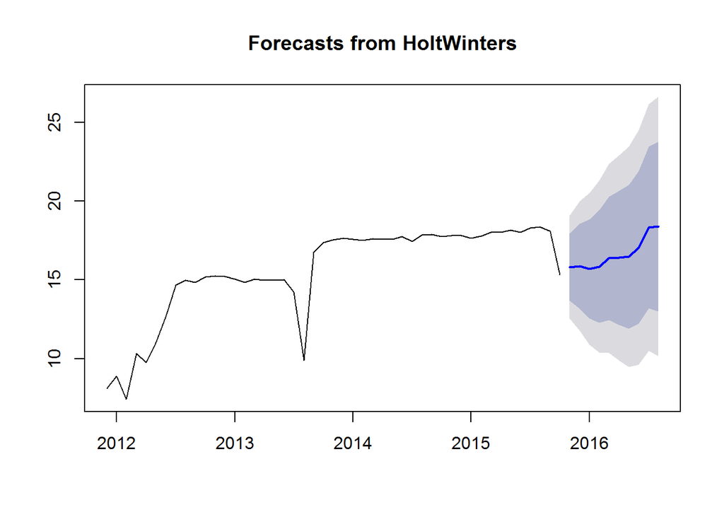

**The forecast are shown as a blue line, and dark grey and light grey shaded areas show 80% and 95% prediction intervals, respectively.**

##### **4.3 Accuracy Estimation**

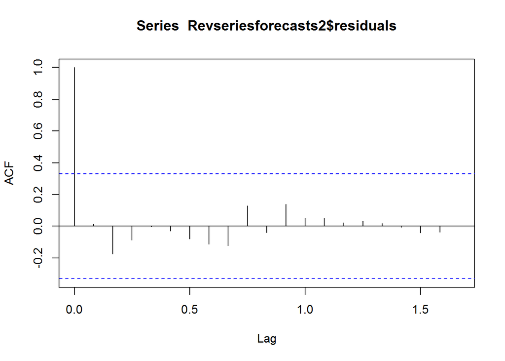

```
##
##  Box-Ljung test
##
## data:  Revseriesforecasts2$residuals
## X-squared = 5.696, df = 20, p-value = 0.9993
```

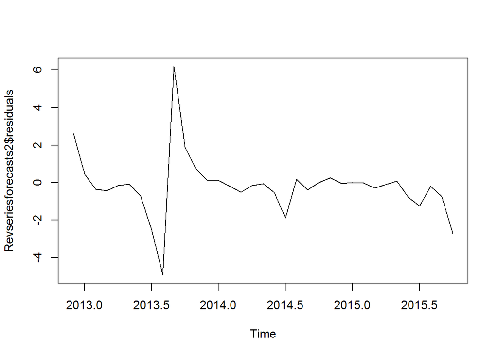

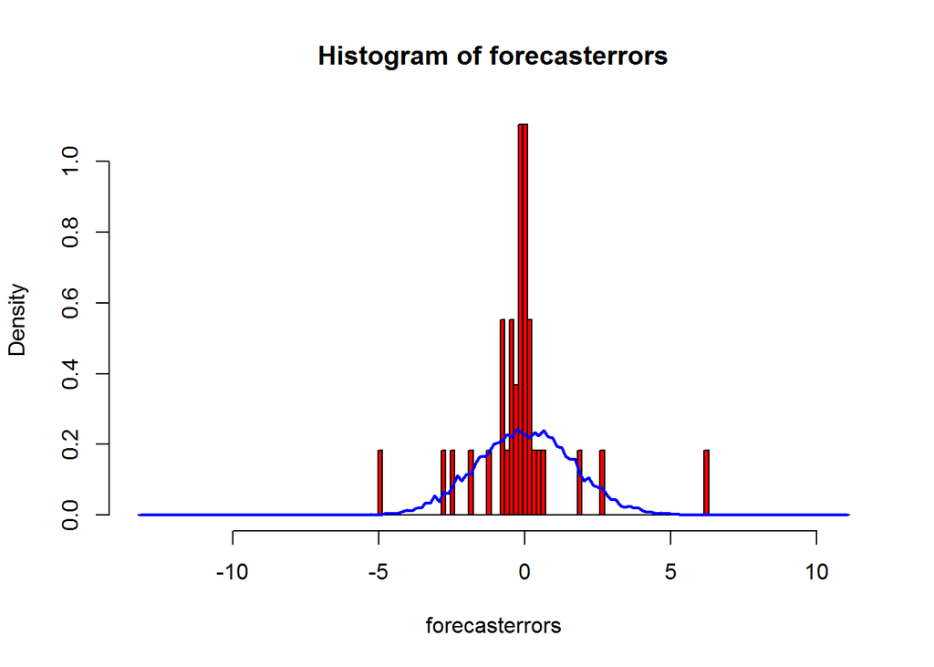

#### 5. ARIMA Model used to make Forecast

**ARIMA models are defined for stationary time series. Therefore, if you start off with a non-stationary time series, you will first need to ‘difference’ the time series until you obtain a stationary time series. If you have to difference the time series d times to obtain a stationary series, then you have an ARIMA(p,d,q) model, where d is the order of differencing used.**

##### **5.1.Difference**

* USing diff(),maybe over and over to be stationary mean, in order to get the stationary time series

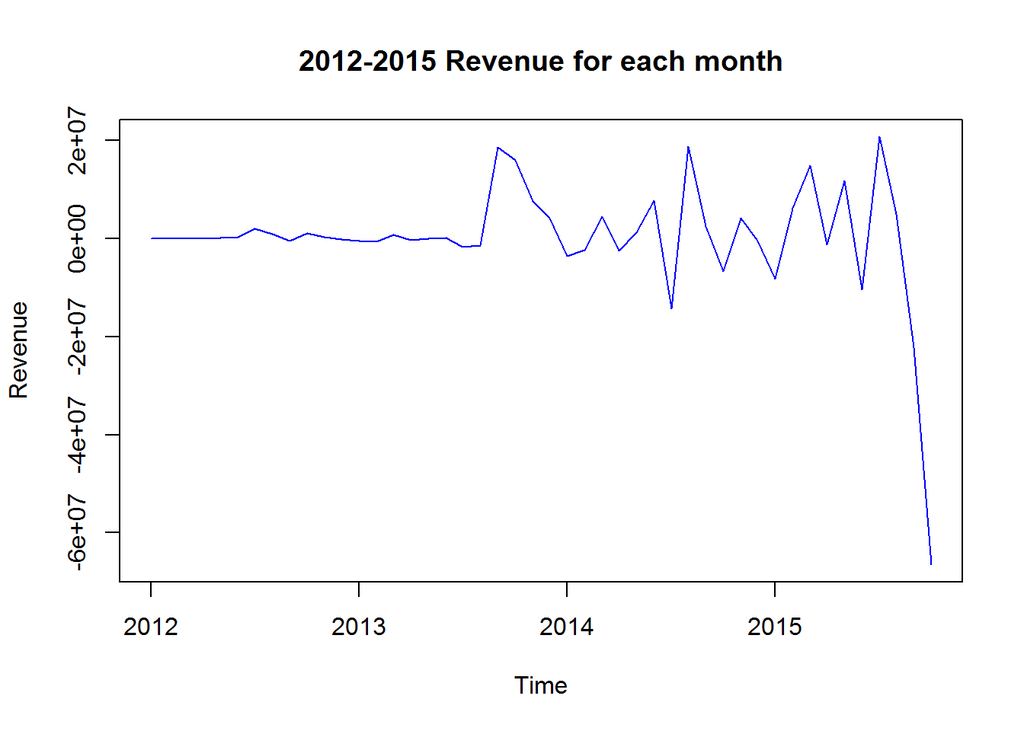

##### **5.2.Select ARIMA Model**

**We need to find appropriate values of p and q for ARIMA(p,d,q) model. To do this, usually need to examine the correlogram and partial correlogram of the stationary time series through “acf()” and “pacf()” respectively.**

* Get the values of autocorrelations

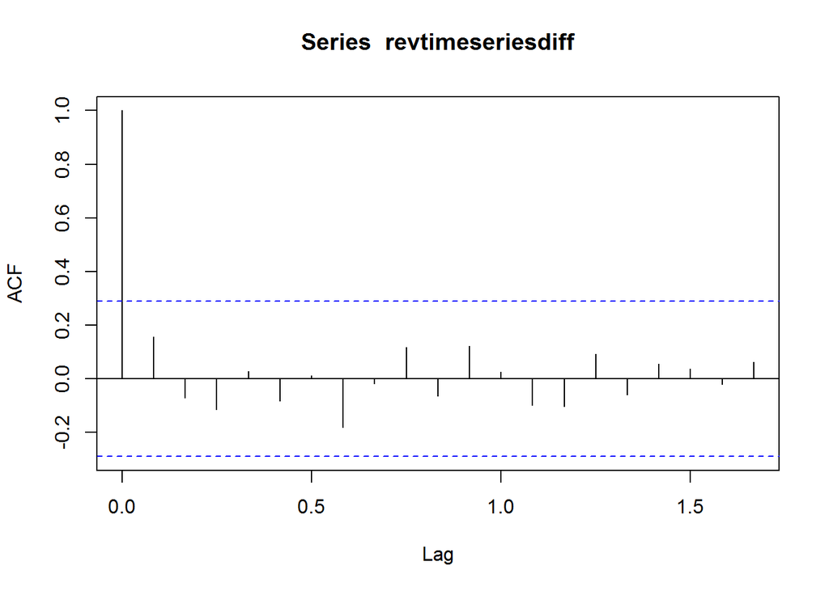

```
##
## Autocorrelations of series 'revtimeseriesdiff', by lag
##
## 0.0000 0.0833 0.1667 0.2500 0.3333 0.4167 0.5000 0.5833 0.6667 0.7500
##  1.000  0.157 -0.070 -0.115  0.029 -0.081  0.012 -0.180 -0.018  0.118
## 0.8333 0.9167 1.0000 1.0833 1.1667 1.2500 1.3333 1.4167 1.5000 1.5833
## -0.064  0.123  0.025 -0.098 -0.103  0.093 -0.059  0.057  0.036 -0.020
## 1.6667
##  0.062
```

**We can see that no lags exceeds the significance bound. and lags tail off to zero.=> q=0**

* Get the values of partial autocorrelations

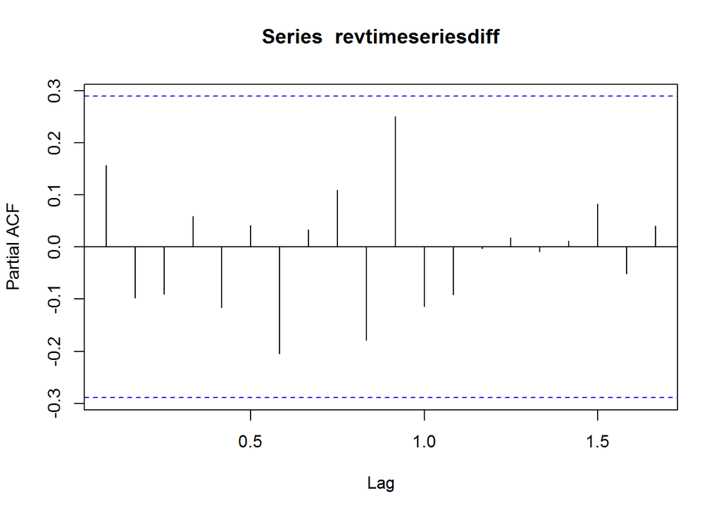

```
##
## Partial autocorrelations of series 'revtimeseriesdiff', by lag
##
## 0.0833 0.1667 0.2500 0.3333 0.4167 0.5000 0.5833 0.6667 0.7500 0.8333
##  0.157 -0.097 -0.091  0.058 -0.116  0.042 -0.205  0.033  0.110 -0.179
## 0.9167 1.0000 1.0833 1.1667 1.2500 1.3333 1.4167 1.5000 1.5833 1.6667
##  0.250 -0.113 -0.091 -0.003  0.018 -0.009  0.011  0.082 -0.051  0.041
```

**We can see that no lags exceeds the significance bound. and lags tail off to zero.=>p=0 ,so we can get ARIMA(0,1,0) model.**

* We can also use the auto.arima() to automatically get the values of p,d and q.

```
## Series: revtimeseries
## ARIMA(1,0,0)(0,1,0)[12]
##
## Coefficients:
##          ar1
##       0.8621
## s.e.  0.0823
##
## sigma^2 estimated as 2.374e+14:  log likelihood=-629.1
## AIC=1262.19   AICc=1262.57   BIC=1265.3
```

**Here we just can get the ARIMA(1,0,0) or ARIMA(0,1,0)**

##### **5.3. Forecast with ARIMA model determined**

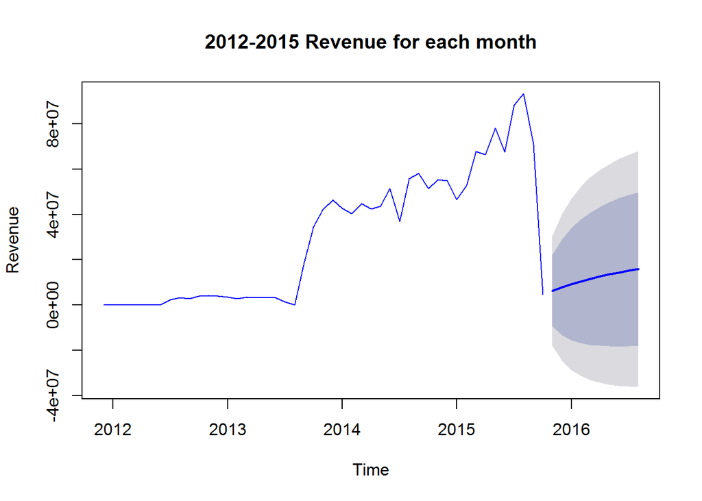

##### **5.4. Test the accuracy of forecast using this ARIMA model**

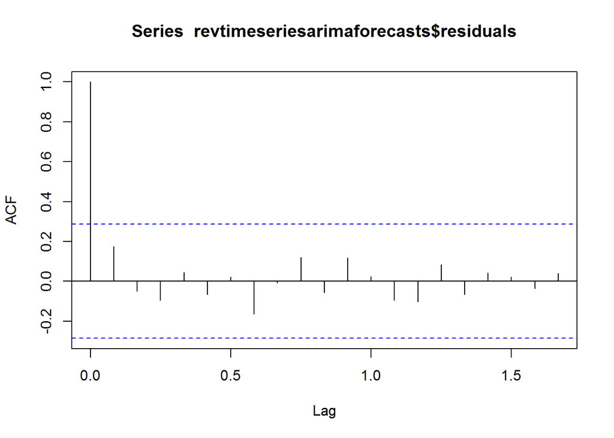

```
##
##  Box-Ljung test
##
## data:  revtimeseriesarimaforecasts$residuals
## X-squared = 8.6255, df = 20, p-value = 0.9869
```

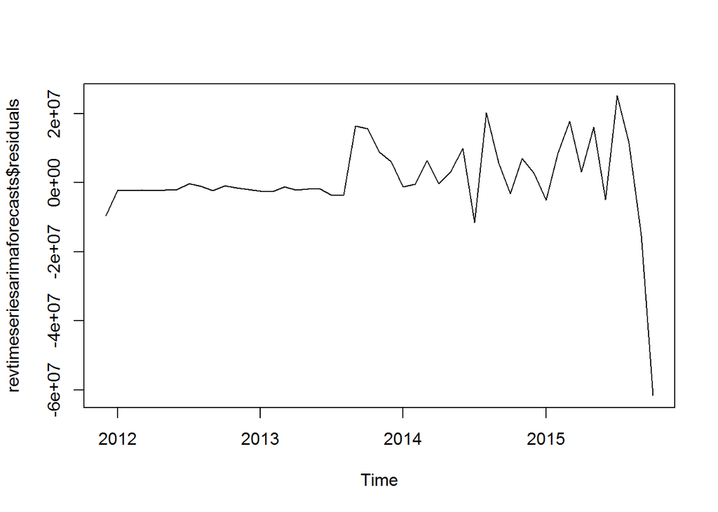

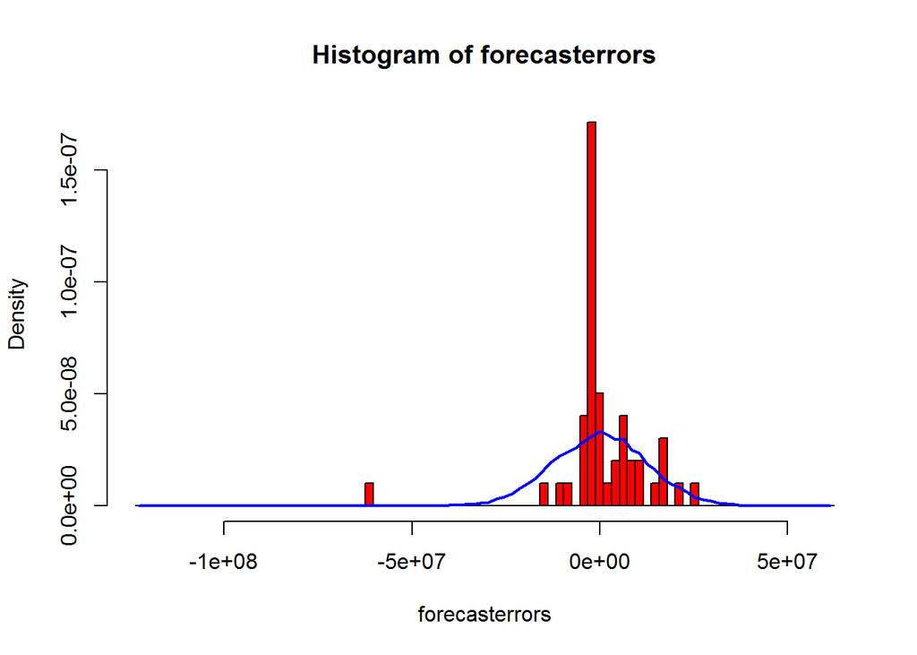

```
## [1] 689711.7
```

##### **5.5.Conclusion**

**Considering IPG revenue time series data has some correlations between successive points of times series(with the ecosystem built up with partners, more patients, physicians, facility and Manufacturers enrolled in this system, revenue will increase with the time going on), ARIMA is more better model to predict the revenue of time series data.**